# Project 2 - Predicting Employee Attrition From HR Data

Allen Crane, Nicholas Cellini, Quincy Roundtree, Heber Nelson, Carter Graves

July 25, 2018

```r
options(width=131)
knitr::opts_chunk$set(echo = TRUE)
```

## Section 1: Answers to Case Study 2 Tasks

### Introduction to this project: DDSAnalytics is an analytics company that specializes in talent management solutions for Fortune 1000 companies. Talent management is defined as the iterative process of developing and retaining employees. It may include workforce planning, employee training programs, identifying high-potential employees and reducing/preventing voluntary employee turnover (attrition). To gain a competitive edge over its competition, DDSAnalytics is planning to leverage data science for talent management. The executive leadership has identified predicting employee turnover as its first application of data science for talent management. Before the business green lights the project, they have tasked your data science team to conduct an analysis of existing employee data.

### Our team has been given a dataset (CaseStudy2-Data.xlsx) to conduct exploratory data analysis (EDA) to determine factors that lead to attrition. Our goal is to identify (at least) the top three factors that contribute to turnover. Additionally, the business is also interested in learning about any job role specific trends that may exist in the data set.

### (Note: Repository steps 1A, 1B, and 1C are contained in the Readme file.)

### 2. Clean the raw data. Set working directory.

### 2A. Read the csv into R and take a look at the data set. Output how many rows and columns the data.frame is.

```r
#install.packages("csvread")
library(csvread)
setwd("~/Qsync/datascience/msds6306_doing_datascience/DDS-CaseStudy-2/Dataset")
workforce.df <- read.csv("CaseStudy2-data.csv", header=TRUE, stringsAsFactors = TRUE, sep = ",")

#Get number of rows in the dataset
nrow(workforce.df)
```

```
## [1] 1470
```

```r
#Get number of columns in the dataset
ncol(workforce.df)
```

```
## [1] 35
```

```r
#View the dataset
head(workforce.df)
```

```
##   Age Attrition    BusinessTravel DailyRate             Department DistanceFromHome Education EducationField EmployeeCount
## 1  41       Yes     Travel_Rarely      1102                  Sales                1         2  Life Sciences             1
## 2  49        No Travel_Frequently       279 Research & Development                8         1  Life Sciences             1
## 3  37       Yes     Travel_Rarely      1373 Research & Development                2         2          Other             1
## 4  33        No Travel_Frequently      1392 Research & Development                3         4  Life Sciences             1
## 5  27        No     Travel_Rarely       591 Research & Development                2         1        Medical             1
## 6  32        No Travel_Frequently      1005 Research & Development                2         2  Life Sciences             1
##   EmployeeNumber EnvironmentSatisfaction Gender HourlyRate JobInvolvement JobLevel               JobRole JobSatisfaction
## 1              1                       2 Female         94              3        2       Sales Executive               4
## 2              2                       3   Male         61              2        2    Research Scientist               2
## 3              4                       4   Male         92              2        1 Laboratory Technician               3
## 4              5                       4 Female         56              3        1    Research Scientist               3
## 5              7                       1   Male         40              3        1 Laboratory Technician               2
## 6              8                       4   Male         79              3        1 Laboratory Technician               4
##   MaritalStatus MonthlyIncome MonthlyRate NumCompaniesWorked Over18 OverTime PercentSalaryHike PerformanceRating
```

[output cut: 20 more lines]

```r
#Summary statistics of the dataset
summary(workforce.df)
```

```
##       Age        Attrition            BusinessTravel   DailyRate                       Department  DistanceFromHome
##  Min.   :18.00   No :1233   Non-Travel       : 150   Min.   : 102.0   Human Resources       : 63   Min.   : 1.000
##  1st Qu.:30.00   Yes: 237   Travel_Frequently: 277   1st Qu.: 465.0   Research & Development:961   1st Qu.: 2.000
##  Median :36.00              Travel_Rarely    :1043   Median : 802.0   Sales                 :446   Median : 7.000
##  Mean   :36.92                                       Mean   : 802.5                                Mean   : 9.193
##  3rd Qu.:43.00                                       3rd Qu.:1157.0                                3rd Qu.:14.000
##  Max.   :60.00                                       Max.   :1499.0                                Max.   :29.000
##
##    Education              EducationField EmployeeCount EmployeeNumber   EnvironmentSatisfaction    Gender      HourlyRate
##  Min.   :1.000   Human Resources : 27    Min.   :1     Min.   :   1.0   Min.   :1.000           Female:588   Min.   : 30.00
##  1st Qu.:2.000   Life Sciences   :606    1st Qu.:1     1st Qu.: 491.2   1st Qu.:2.000           Male  :882   1st Qu.: 48.00
##  Median :3.000   Marketing       :159    Median :1     Median :1020.5   Median :3.000                        Median : 66.00
##  Mean   :2.913   Medical         :464    Mean   :1     Mean   :1024.9   Mean   :2.722                        Mean   : 65.89
##  3rd Qu.:4.000   Other           : 82    3rd Qu.:1     3rd Qu.:1555.8   3rd Qu.:4.000                        3rd Qu.: 83.75
##  Max.   :5.000   Technical Degree:132    Max.   :1     Max.   :2068.0   Max.   :4.000                        Max.   :100.00
##
##  JobInvolvement    JobLevel                          JobRole    JobSatisfaction  MaritalStatus MonthlyIncome    MonthlyRate
##  Min.   :1.00   Min.   :1.000   Sales Executive          :326   Min.   :1.000   Divorced:327   Min.   : 1009   Min.   : 2094
##  1st Qu.:2.00   1st Qu.:1.000   Research Scientist       :292   1st Qu.:2.000   Married :673   1st Qu.: 2911   1st Qu.: 8047
##  Median :3.00   Median :2.000   Laboratory Technician    :259   Median :3.000   Single  :470   Median : 4919   Median :14236
##  Mean   :2.73   Mean   :2.064   Manufacturing Director   :145   Mean   :2.729                  Mean   : 6503   Mean   :14313
##  3rd Qu.:3.00   3rd Qu.:3.000   Healthcare Representative:131   3rd Qu.:4.000                  3rd Qu.: 8379   3rd Qu.:20462
##  Max.   :4.00   Max.   :5.000   Manager                  :102   Max.   :4.000                  Max.   :19999   Max.   :26999
##                                 (Other)                  :215
##  NumCompaniesWorked Over18   OverTime   PercentSalaryHike PerformanceRating RelationshipSatisfaction StandardHours
##  Min.   :0.000      Y:1470   No :1054   Min.   :11.00     Min.   :3.000     Min.   :1.000            Min.   :80
##  1st Qu.:1.000               Yes: 416   1st Qu.:12.00     1st Qu.:3.000     1st Qu.:2.000            1st Qu.:80
##  Median :2.000                          Median :14.00     Median :3.000     Median :3.000            Median :80
##  Mean   :2.693                          Mean   :15.21     Mean   :3.154     Mean   :2.712            Mean   :80
##  3rd Qu.:4.000                          3rd Qu.:18.00     3rd Qu.:3.000     3rd Qu.:4.000            3rd Qu.:80
##  Max.   :9.000                          Max.   :25.00     Max.   :4.000     Max.   :4.000            Max.   :80
##
##  StockOptionLevel TotalWorkingYears TrainingTimesLastYear WorkLifeBalance YearsAtCompany   YearsInCurrentRole
##  Min.   :0.0000   Min.   : 0.00     Min.   :0.000         Min.   :1.000   Min.   : 0.000   Min.   : 0.000
##  1st Qu.:0.0000   1st Qu.: 6.00     1st Qu.:2.000         1st Qu.:2.000   1st Qu.: 3.000   1st Qu.: 2.000
##  Median :1.0000   Median :10.00     Median :3.000         Median :3.000   Median : 5.000   Median : 3.000
##  Mean   :0.7939   Mean   :11.28     Mean   :2.799         Mean   :2.761   Mean   : 7.008   Mean   : 4.229
##  3rd Qu.:1.0000   3rd Qu.:15.00     3rd Qu.:3.000         3rd Qu.:3.000   3rd Qu.: 9.000   3rd Qu.: 7.000
##  Max.   :3.0000   Max.   :40.00     Max.   :6.000         Max.   :4.000   Max.   :40.000   Max.   :18.000
##
##  YearsSinceLastPromotion YearsWithCurrManager
##  Min.   : 0.000          Min.   : 0.000
##  1st Qu.: 0.000          1st Qu.: 2.000
##  Median : 1.000          Median : 3.000
##  Mean   : 2.188          Mean   : 4.123
##  3rd Qu.: 3.000          3rd Qu.: 7.000
##  Max.   :15.000          Max.   :17.000
##
```

### 2B. The column names are either too much or not enough. Change the column names so that they do not have spaces, underscores, slashes, and the like. All column names should be under 12 characters. Make sure you’re updating your codebook with information on the tidied data set as well.

### (Note: 2C. Some columns are, due to Qualtrics, malfunctioning.)

```r
colnames(workforce.df) <- c("Age", "Attrition", "BusTravel", "DayRate", "Department", "DistFromHome", "Education", "EducField", "EmpCount", "EmpNumber", "EnvironSat", "Gender", "HourRate", "JobInvolve", "JobLevel", "JobRole", "JobSat", "MaritalStat", "MonthInc", "MonthRate", "NumCompWrkd", "Over18", "OverTime", "PctSalHike", "PerfRating", "RelationSat", "StdHours", "StkOptLvl", "TotWorkYrs", "TrngTmLstYr", "WrkLifBal", "YrsAtComp", "YrsCurRole", "YrsLstPromo", "YrsCurrMgr")
head(workforce.df)
```

```
##   Age Attrition         BusTravel DayRate             Department DistFromHome Education     EducField EmpCount EmpNumber
## 1  41       Yes     Travel_Rarely    1102                  Sales            1         2 Life Sciences        1         1
## 2  49        No Travel_Frequently     279 Research & Development            8         1 Life Sciences        1         2
## 3  37       Yes     Travel_Rarely    1373 Research & Development            2         2         Other        1         4
## 4  33        No Travel_Frequently    1392 Research & Development            3         4 Life Sciences        1         5
## 5  27        No     Travel_Rarely     591 Research & Development            2         1       Medical        1         7
## 6  32        No Travel_Frequently    1005 Research & Development            2         2 Life Sciences        1         8
##   EnvironSat Gender HourRate JobInvolve JobLevel               JobRole JobSat MaritalStat MonthInc MonthRate NumCompWrkd Over18
## 1          2 Female       94          3        2       Sales Executive      4      Single     5993     19479           8      Y
## 2          3   Male       61          2        2    Research Scientist      2     Married     5130     24907           1      Y
## 3          4   Male       92          2        1 Laboratory Technician      3      Single     2090      2396           6      Y
## 4          4 Female       56          3        1    Research Scientist      3     Married     2909     23159           1      Y
## 5          1   Male       40          3        1 Laboratory Technician      2     Married     3468     16632           9      Y
## 6          4   Male       79          3        1 Laboratory Technician      4      Single     3068     11864           0      Y
##   OverTime PctSalHike PerfRating RelationSat StdHours StkOptLvl TotWorkYrs TrngTmLstYr WrkLifBal YrsAtComp YrsCurRole YrsLstPromo
## 1      Yes         11          3           1       80         0          8           0         1         6          4           0
## 2       No         23          4           4       80         1         10           3         3        10          7           1
## 3      Yes         15          3           2       80         0          7           3         3         0          0           0
## 4      Yes         11          3           3       80         0          8           3         3         8          7           3
## 5       No         12          3           4       80         1          6           3         3         2          2           2
## 6       No         13          3           3       80         0          8           2         2         7          7           3
##   YrsCurrMgr
## 1          5
## 2          7
## 3          0
## 4          0
## 5          2
## 6          6
```

### 2D. Make sure your columns are the proper data types (i.e., numeric, character, etc.). If they are incorrect, convert them.

```r
sapply(workforce.df, class)
```

```
##          Age    Attrition    BusTravel      DayRate   Department DistFromHome    Education    EducField     EmpCount    EmpNumber
##    "integer"     "factor"     "factor"    "integer"     "factor"    "integer"    "integer"     "factor"    "integer"    "integer"
##   EnvironSat       Gender     HourRate   JobInvolve     JobLevel      JobRole       JobSat  MaritalStat     MonthInc    MonthRate
##    "integer"     "factor"    "integer"    "integer"    "integer"     "factor"    "integer"     "factor"    "integer"    "integer"
##  NumCompWrkd       Over18     OverTime   PctSalHike   PerfRating  RelationSat     StdHours    StkOptLvl   TotWorkYrs  TrngTmLstYr
##    "integer"     "factor"     "factor"    "integer"    "integer"    "integer"    "integer"    "integer"    "integer"    "integer"
##    WrkLifBal    YrsAtComp   YrsCurRole  YrsLstPromo   YrsCurrMgr
##    "integer"    "integer"    "integer"    "integer"    "integer"
```

#### After inspecting the class of each of our variables, we see a mix of integer/numeric data and character/factor data.

### 3.Preliminary Analysis.

### 3A.Remove all observations where the participant is under age 18. No further analysis of underage individuals is permitted by your client. Remove any other age outliers as you see fit, but be sure to tell what you’re doing and why.

```r
summary(workforce.df$Over18)
```

```
##    Y
## 1470
```

#### After inspecting the values in the Over18 variable, we find that there are no individuals that are under 18. We will proceed with the analysis.

### 3B.Please provide (in table format or similar), descriptive statistics on at least 7 variables (Age, Monthly Income, etc.). Create a simple histogram for two of them. Comment on the shape of the distribution in your markdown.

```r
#create descriptive statistics

#install.packages("pastecs")
library(pastecs)
attach(workforce.df)
scores <- cbind(Age, Attrition, BusTravel, Department, DistFromHome, Education, EducField, MonthRate)
options(scipen=100)
options(digits=2)
stat.desc(scores, basic=F)
```

```
##                Age Attrition BusTravel Department DistFromHome Education EducField  MonthRate
## median       36.00    1.0000     3.000      2.000         7.00     3.000     3.000    14235.5
## mean         36.92    1.1612     2.607      2.261         9.19     2.913     3.248    14313.1
## SE.mean       0.24    0.0096     0.017      0.014         0.21     0.027     0.035      185.6
## CI.mean.0.95  0.47    0.0188     0.034      0.027         0.41     0.052     0.068      364.2
## var          83.46    0.1353     0.443      0.279        65.72     1.049     1.773 50662878.2
## std.dev       9.14    0.3679     0.665      0.528         8.11     1.024     1.331     7117.8
## coef.var      0.25    0.3168     0.255      0.233         0.88     0.352     0.410        0.5
```

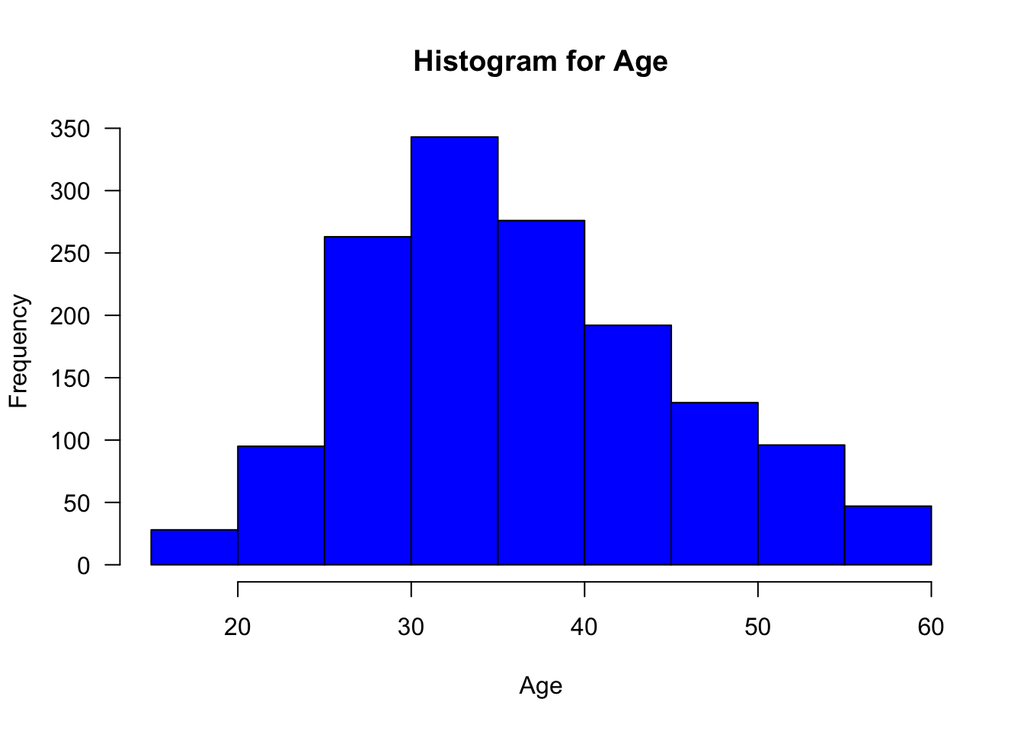

```r
#create historgrams (Age and Monthly Income)

#install.packages("ggplot2")
library(ggplot2)
hist(workforce.df$Age,
     main="Histogram for Age",
     xlab="Age",
     col="blue",
     las=1,
     breaks=10)
```

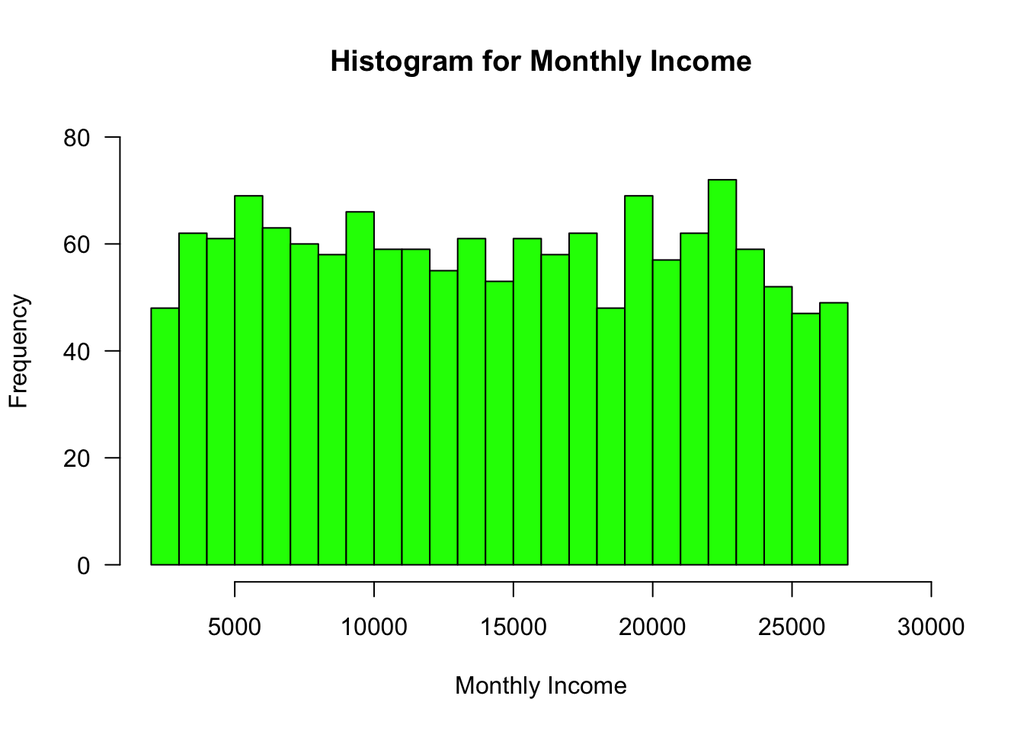

```r
hist(workforce.df$MonthRate,
     main="Histogram for Monthly Income",
     xlab="Monthly Income",
     xlim=c(2000,30000),
     ylim=c(0,80),
     col="green",
     las=1,
     breaks=25)
```

### 3C. Give the frequencies (in table format or similar) for Gender, Education, and Occupation. They can be separate tables, if that’s your choice.

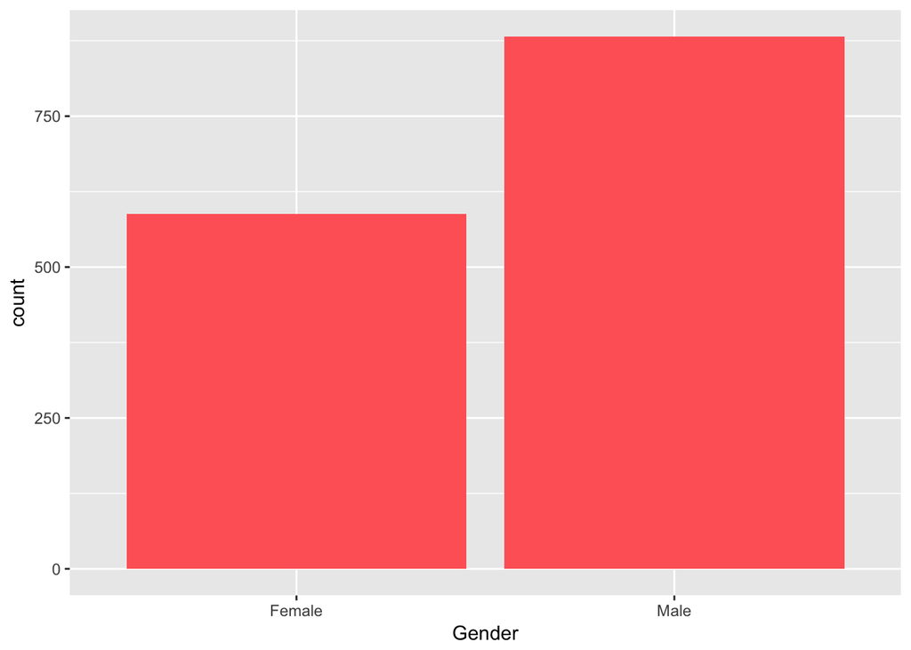

```r
ggplot(data.frame(workforce.df),aes(x=Gender)) + geom_bar(fill = "#FF6666")
```

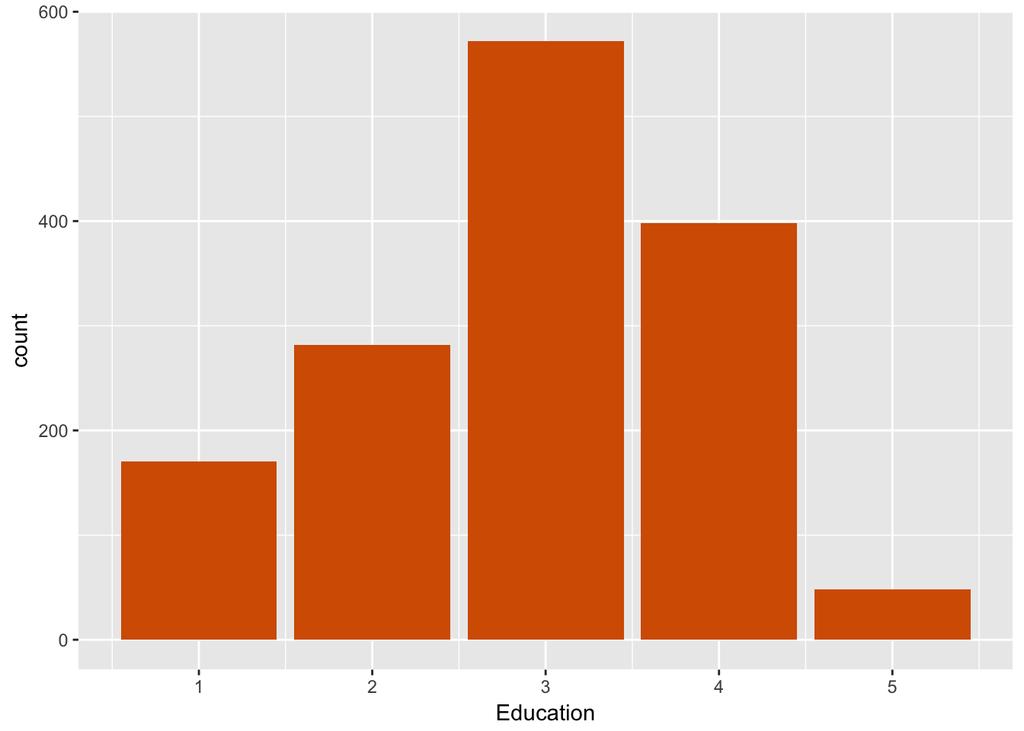

```r
ggplot(data.frame(workforce.df),aes(x=Education)) + geom_bar(fill = "#D55E00")
```

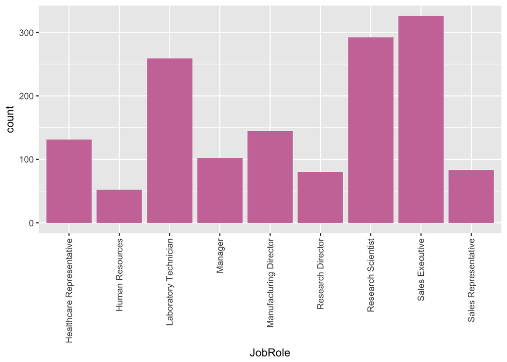

```r
ggplot(data.frame(workforce.df),aes(x=JobRole)) + geom_bar(fill = "#CC79A7") + theme(axis.text.x=element_text(angle=90,hjust=1,vjust=0.5))
```

### 3D.Give the counts (again, table) of management positions.

```r
with(droplevels(workforce.df[which(workforce.df$JobRole!= "Healthcare Representative" & workforce.df$JobRole!= "Human Resources" & workforce.df$JobRole!= "Laboratory Technician" & workforce.df$JobRole!= "Research Scientist" & workforce.df$JobRole!= "Sales Representative"),]), summary(JobRole))
```

```
##                Manager Manufacturing Director      Research Director        Sales Executive
##                    102                    145                     80                    326
```

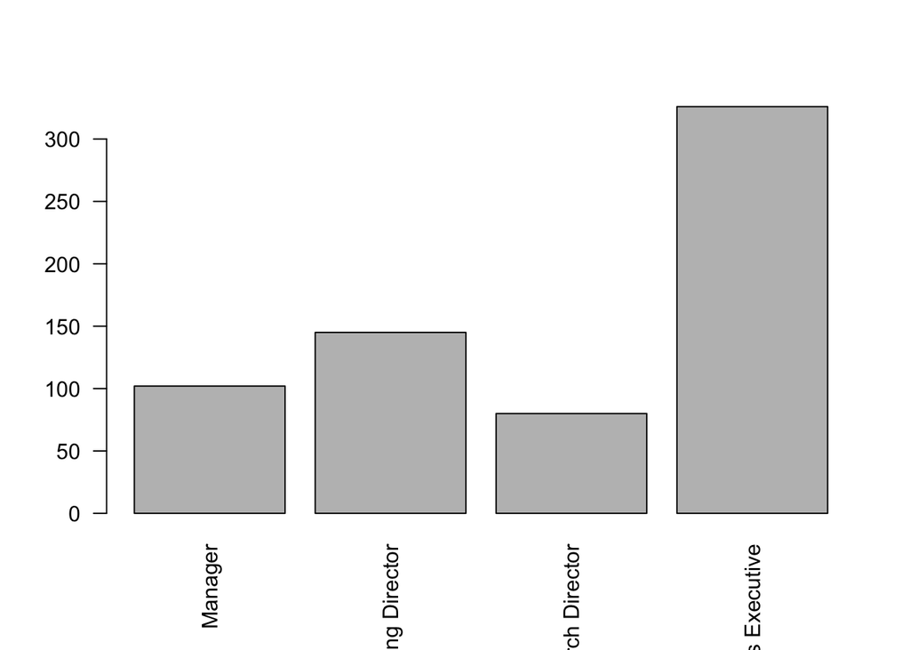

```r
with(droplevels(workforce.df[which(workforce.df$JobRole!= "Healthcare Representative" & workforce.df$JobRole!= "Human Resources" & workforce.df$JobRole!= "Laboratory Technician" & workforce.df$JobRole!= "Research Scientist" & workforce.df$JobRole!= "Sales Representative"),]),
plot(JobRole, las=2, cex.xaxis=0.8))
```

### 4.Deeper Analysis and Visualization

### 4A. (Note: You should make all of these appealing looking. Remember to include things like a clean, informative title, axis labels that are in plain English, and readable axis values that do not overlap.)

### 4B. Create bar charts in ggplot or similar. The bars should be in descending order, Use any color palette of your choice other than the default. (Note: See Regression Coefficients output from Predictive Model summary below)

### 4C. Is there a relationship between Age and Income? Create a scatterplot and make an assessment of whether there is a relationship. Color each point based on the Gender of the participant. You’re welcome to use lm() or similar functions to back up your claims.

```r
model2 <- lm(MonthRate ~ Age, data=workforce.df)
summary(model2)
```

```
##
## Call:
## lm(formula = MonthRate ~ Age, data = workforce.df)
##
## Residuals:
##    Min     1Q Median     3Q    Max
## -12452  -6193    -45   6111  13056
##
## Coefficients:
##             Estimate Std. Error t value            Pr(>|t|)
## (Intercept)  13506.1      773.2   17.47 <0.0000000000000002 ***
## Age             21.9       20.3    1.08                0.28
## ---
## Signif. codes:  0 '***' 0.001 '**' 0.01 '*' 0.05 '.' 0.1 ' ' 1
##
## Residual standard error: 7120 on 1468 degrees of freedom
## Multiple R-squared:  0.000787,   Adjusted R-squared:  0.000106
## F-statistic: 1.16 on 1 and 1468 DF,  p-value: 0.282
```

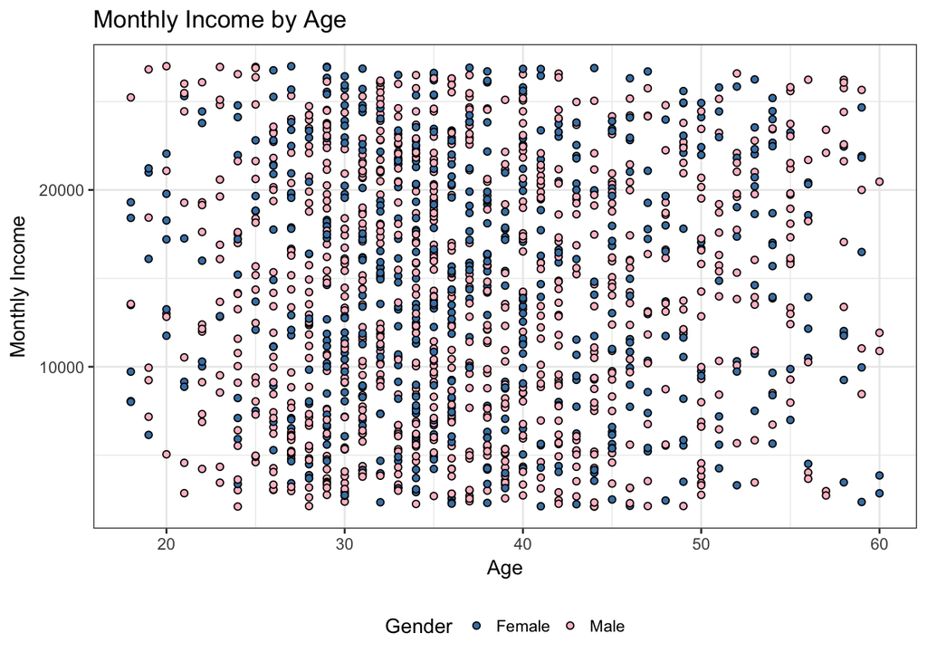

```r
fill = c("steelblue", "pink")
library(ggplot2)
model2_plot <- ggplot(workforce.df, aes(Age, MonthRate, fill = Gender)) +
  geom_point(shape = 21) +
  theme_bw() +
  theme() +
  ggtitle("Monthly Income by Age") +
  labs(x = "Age", y = "Monthly Income", fill = "Gender") +
  scale_fill_manual(values = fill) +
  scale_size(range = c(1, 10)) +
  theme(legend.position="bottom", legend.direction="horizontal")
model2_plot
```

## Section 2: Building the model to predict Attrition

### The following is our approach to build a predictive model for Attrition. This will form the basis of our recommendation in our presentation.

### Add row number to master, and insert as a unique column into data set. We will break out the master file into a factor data set and a categorical data set. The categorical data set will be flattened into a one hot encoded file. Preserving the ID column allows us something to join on, when we merge these files back together when we build the model.

```r
library(tidyverse)
workforce.df <- tibble::rowid_to_column(workforce.df, "ID")
```

### Split data set into factors and categories, including row IDs

```r
workforce_factors.df <- workforce.df[c(1,2,3,5,7,10,11,14,20,21,22,25,28,30,31,33,34,35,36)]
workforce_categories.df <- workforce.df[c(1,3,4,6,8,9,12,13,15,16,17,18,19,23,24,25,27,29,32)]
```

### One hot encoding for categorical data

```r
#install.packages("data.table")
library(data.table)
workforce_categories_onehot.df <- dcast(melt(workforce_categories.df, id.vars='ID'), ID ~ variable + value, fun = length)
```

### Merge data files together

```r
workforce_ohe.df <- merge(workforce_factors.df, workforce_categories_onehot.df, by="ID")
```

### Remove the Attrition categorical variables, because they are perfectly correlated values

```r
workforce_ohe.df$Attrition <- NULL
workforce_ohe.df$Attrition_No <- NULL
```

### The following modeling code was adapted from: https://datascienceplus.com/perform-logistic-regression-in-r/

### A visual take on the missing values might be helpful: the Amelia package has a special plotting function missmap() that will plot your dataset and highlight missing values. In our case, this adds nothing meaningful.

```r
#library(Amelia)
#missmap(workforce_ohe.df, main = "Missing values vs observed")
```

### We split the data into two chunks: training and testing set. The training set will be used to fit our model which we will be testing over the testing set. Note that the training data set is ~2/3 the size of the total data, because a training set at 1/2 the size of the total data did not converge.

```r
workforce_ohe_train.df <- workforce_ohe.df[1:1000,]
workforce_ohe_test.df <- workforce_ohe.df[1001:1470,]
```

### Now, let’s fit the model. Be sure to specify the parameter family=binomial in the glm() function. Note that we upped the max iterations to 50, in order to override the default number of iterations. That said, this model converges at 15 iterations.

```r
model <- glm(Attrition_Yes ~.,family=binomial(link='logit'),data=workforce_ohe_train.df, control=list(maxit=50))
```

### By using function summary() we obtain the results of our model:

```r
summary(model)
```

```
##
## Call:
## glm(formula = Attrition_Yes ~ ., family = binomial(link = "logit"),
##     data = workforce_ohe_train.df, control = list(maxit = 50))
##
## Deviance Residuals:
##    Min      1Q  Median      3Q     Max
## -2.078  -0.407  -0.169  -0.045   3.354
##
## Coefficients: (20 not defined because of singularities)
##                                        Estimate  Std. Error z value             Pr(>|z|)
## (Intercept)                          24.9455079  39.7408722    0.63              0.53020
## ID                                    0.0051986   0.0216385    0.24              0.81014
## Age                                  -0.0415947   0.0179884   -2.31              0.02076 *
## DayRate                              -0.0004006   0.0003054   -1.31              0.18964
## DistFromHome                          0.0547109   0.0147769    3.70              0.00021 ***
## EmpCount                                     NA          NA      NA                   NA
## EmpNumber                            -0.0035458   0.0153621   -0.23              0.81746
## HourRate                              0.0032563   0.0063710    0.51              0.60927
## MonthInc                             -0.0001666   0.0001278   -1.30              0.19221
## MonthRate                             0.0000334   0.0000172    1.94              0.05185 .
## NumCompWrkd                           0.2413122   0.0534599    4.51            0.0000064 ***
## PctSalHike                           -0.8803155   1.6276806   -0.54              0.58862
## StdHours                                     NA          NA      NA                   NA
## TotWorkYrs                           -0.0669159   0.0402574   -1.66              0.09647 .
## TrngTmLstYr                          -0.1200553   0.0940823   -1.28              0.20193
## YrsAtComp                             0.0904077   0.0509838    1.77              0.07619 .
## YrsCurRole                           -0.1171888   0.0646536   -1.81              0.06990 .
## YrsLstPromo                           0.1927718   0.0578039    3.33              0.00085 ***
## YrsCurrMgr                           -0.1840363   0.0623523   -2.95              0.00316 **
## `BusTravel_Non-Travel`               -0.9630041   0.4875052   -1.98              0.04823 *
## BusTravel_Travel_Frequently           0.9615042   0.2908421    3.31              0.00095 ***
## BusTravel_Travel_Rarely                      NA          NA      NA                   NA
## `Department_Human Resources`        -12.5328786 660.4457247   -0.02              0.98486
## `Department_Research & Development`   0.9731797   1.3673636    0.71              0.47664
## Department_Sales                             NA          NA      NA                   NA
## Education_1                           1.6612127   1.2428641    1.34              0.18135
## Education_2                           1.5505844   1.2331240    1.26              0.20859
## Education_3                           1.8241630   1.2160137    1.50              0.13358
## Education_4                           1.9490391   1.2244683    1.59              0.11144
```

[output cut: 63 more lines]

```
## StkOptLvl_3                                  NA          NA      NA                   NA
## WrkLifBal_1                           1.2510895   0.6054349    2.07              0.03879 *
## WrkLifBal_2                           0.2666145   0.4449979    0.60              0.54908
## WrkLifBal_3                          -0.4931286   0.4018716   -1.23              0.21979
## WrkLifBal_4                                  NA          NA      NA                   NA
## ---
## Signif. codes:  0 '***' 0.001 '**' 0.01 '*' 0.05 '.' 0.1 ' ' 1
##
## (Dispersion parameter for binomial family taken to be 1)
##
##     Null deviance: 902.19  on 999  degrees of freedom
## Residual deviance: 502.57  on 923  degrees of freedom
## AIC: 656.6
##
## Number of Fisher Scoring iterations: 15
```

### In the following steps, we format the model outputs to create a list of the top coefficients, by the absolute Z Score values.

```r
#Output Coefficients of the model into a data frame. We will format these to graph the top Coefficient values
#install.packages("broom")
library(broom)
model_output.df <- tidy(model)

#Create Model Output 2 file of Coefficients and Z Scores
model_output2.df <- data.frame(model_output.df$term, model_output.df$statistic)
colnames(model_output2.df) <- c("term", "statistic")
head(model_output2.df)
```

```
##           term statistic
## 1  (Intercept)      0.63
## 2           ID      0.24
## 3          Age     -2.31
## 4      DayRate     -1.31
## 5 DistFromHome      3.70
## 6    EmpNumber     -0.23
```

```r
#Create Model Output 3 file of Top 10 Coefficients by absolute value of Z Scores
#install.packages("dplyr")
library(dplyr)
model_output3.df <- top_n(model_output2.df, 10, abs(model_output2.df$statistic))
head(model_output3.df)
```

```
##                          term statistic
## 1                DistFromHome       3.7
## 2                 NumCompWrkd       4.5
## 3                 YrsLstPromo       3.3
## 4 BusTravel_Travel_Frequently       3.3
## 5   `EducField_Life Sciences`      -3.3
## 6                EnvironSat_1       4.7
```

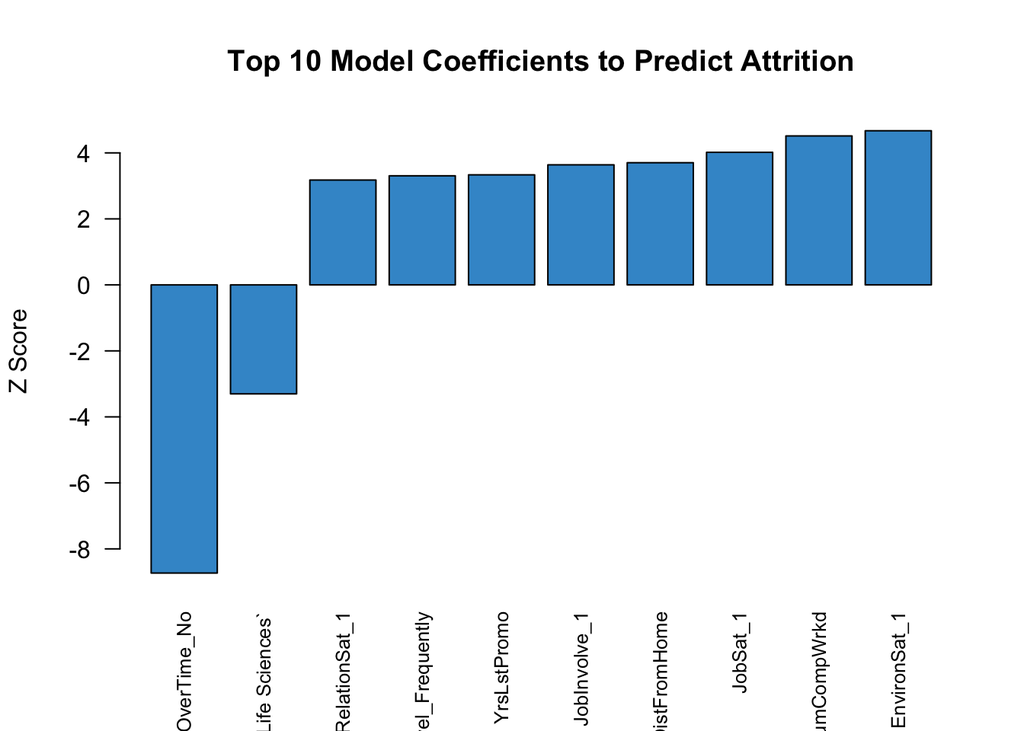

```r
#Create Model Output 4 file that sorts the Top 10 Coefficients for graphing
model_output4.df <- model_output3.df[order(model_output3.df$statistic,decreasing = FALSE),]

#Graph the Top 10 Coefficients by Z Score
ylim <- c(-9,5)
barplot(model_output4.df$statistic, col="#3F97D0", main="Top 10 Model Coefficients to Predict Attrition", ylab="Z Score", names.arg=model_output4.df$term, cex.names=0.8, las=2, ylim = ylim)
```

```r
model_output2.df <- data.frame(model_output.df$term, model_output.df$statistic)
```

## Section 3: Validating the model for fit

### Now we can run the anova() function on the model to analyze the table of deviance

```r
anova(model, test="Chisq")
```

```
## Analysis of Deviance Table
##
## Model: binomial, link: logit
##
## Response: Attrition_Yes
##
## Terms added sequentially (first to last)
##
##
##                                     Df Deviance Resid. Df Resid. Dev             Pr(>Chi)
## NULL                                                  999        902
## ID                                   1      0.7       998        901              0.39515
## Age                                  1     30.0       997        872          0.000000044 ***
## DayRate                              1      2.2       996        869              0.13612
## DistFromHome                         1      6.3       995        863              0.01230 *
## EmpCount                             0      0.0       995        863
## EmpNumber                            1      0.0       994        863              0.83960
## HourRate                             1      0.2       993        863              0.63422
## MonthInc                             1     10.5       992        852              0.00120 **
## MonthRate                            1      0.3       991        852              0.60233
## NumCompWrkd                          1     11.7       990        840              0.00064 ***
## PctSalHike                           1      0.0       989        840              0.87721
## StdHours                             0      0.0       989        840
## TotWorkYrs                           1      3.2       988        837              0.07492 .
## TrngTmLstYr                          1      1.2       987        836              0.27921
## YrsAtComp                            1      0.0       986        836              0.87324
## YrsCurRole                           1     10.6       985        825              0.00112 **
## YrsLstPromo                          1      7.2       984        818              0.00736 **
## YrsCurrMgr                           1      4.9       983        813              0.02632 *
## `BusTravel_Non-Travel`               1      7.2       982        806              0.00741 **
## BusTravel_Travel_Frequently          1      5.6       981        800              0.01835 *
## BusTravel_Travel_Rarely              0      0.0       981        800
## `Department_Human Resources`         1      0.0       980        800              0.86972
## `Department_Research & Development`  1      6.4       979        794              0.01139 *
## Department_Sales                     0      0.0       979        794
## Education_1                          1      0.0       978        794              0.97708
## Education_2                          1      0.4       977        794              0.54358
## Education_3                          1      0.2       976        793              0.63986
## Education_4                          1      4.1       975        789              0.04247 *
## Education_5                          0      0.0       975        789
```

[output cut: 54 more lines]

```
## PctSalHike_25                        0      0.0       932        541
## RelationSat_1                        1     12.2       931        529              0.00049 ***
## RelationSat_2                        1      0.1       930        529              0.74933
## RelationSat_3                        1      0.0       929        529              0.84888
## RelationSat_4                        0      0.0       929        529
## StkOptLvl_0                          1      9.3       928        520              0.00226 **
## StkOptLvl_1                          1      0.6       927        519              0.44490
## StkOptLvl_2                          1      0.8       926        518              0.38580
## StkOptLvl_3                          0      0.0       926        518
## WrkLifBal_1                          1      8.5       925        510              0.00365 **
## WrkLifBal_2                          1      5.7       924        504              0.01661 *
## WrkLifBal_3                          1      1.5       923        503              0.22609
## WrkLifBal_4                          0      0.0       923        503
## ---
## Signif. codes:  0 '***' 0.001 '**' 0.01 '*' 0.05 '.' 0.1 ' ' 1
```

### While no exact equivalent to the R2 of linear regression exists, the McFadden R2 index can be used to assess the model fit.

```r
#install.packages("pscl")
library(pscl)
pR2(model)
```

```
##      llh  llhNull       G2 McFadden     r2ML     r2CU
##  -251.28  -451.10   399.63     0.44     0.33     0.55
```

### Assessing the predictive ability of the model: In the steps above, we briefly evaluated the fitting of the model, now we would like to see how the model is doing when predicting y on a new set of data. By setting the parameter type=‘response’, R will output probabilities in the form of P(y=1|X). Our decision boundary will be 0.5. If P(y=1|X) > 0.5 then y = 1 otherwise y=0. Note that for some applications different decision boundaries could be a better option.

```r
fitted.results <- predict(model,newdata=subset(workforce_ohe_test.df,type='response'))
fitted.results <- ifelse(fitted.results > 0.5,1,0)
misClasificError <- mean(fitted.results != workforce_ohe_test.df$Attrition_Yes)
print(paste('Accuracy',1-misClasificError))
```

```
## [1] "Accuracy 0.895744680851064"
```

### As a last step, we are going to plot the ROC curve and calculate the AUC (area under the curve) which are typical performance measurements for a binary classifier. The ROC is a curve generated by plotting the true positive rate (TPR) against the false positive rate (FPR) at various threshold settings while the AUC is the area under the ROC curve. As a rule of thumb, a model with good predictive ability should have an AUC closer to 1 (1 is ideal) than to 0.5.

```r
#install.packages("ROCR")
library(ROCR)
p <- predict(model, newdata=subset(workforce_ohe_test.df, type="response"))
```

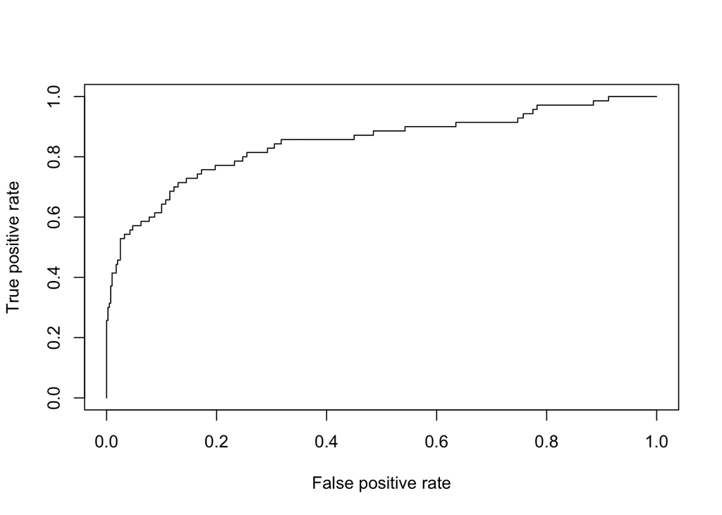

```r
pr <- prediction(p, workforce_ohe_test.df$Attrition)
prf <- performance(pr, measure = "tpr", x.measure = "fpr")
plot(prf)
```

```r
auc <- performance(pr, measure = "auc")
auc <- auc@y.values[[1]]
auc
```

```
## [1] 0.85
```